# Tutorial for immunoediting model of selection using dN/dS

Luis Zapata

2021-03-08

# dNdSSimulator

dNdS Simulator uses R to simulate a stochastic branching process with a set of genotypes and phenotypes per cell. The main advantage of the model is that simulates immunoediting by introducing immunogenic and escape mutations as well as driver and passenger mutations.

## Installation dN/dS simulation package

We must first clone our repository, load libraries and functions for the simulation:

```bash
git clone github.com/luisgls/dNdSSimulator .
```

```r
library(ggpubr)
library(tidyverse)
library(ggmuller)
library(crayon)
library(pio)
library(easypar)
library(parallel)
source('simulator_modelA.R')
source("functions_ZCsimulator.R")
source("simulator_plotting.R")
```

## Running one simulation

As an example, we will run the simulator using the following paramters:

```r
######### Number of simulations that we will perform #########
TASKS = 1

######## Define a Null set of parameters for our evolutionary model ###########
params = NULL

####Define initial population size (number of wild-type cells)
params['n0'] <- 5

######## Global parameter to stop simulation after N generations #########
params['GENERATIONS'] = 50

######## Global parameter to stop simulation after K number of alive cells #########
params['Kcapacity'] = 500

####### Set probability of cell survival #########
params['ps'] <- 0.5
params['pdiff'] <- (1 - params['ps'])

###### Set mutation rate parameter, the final mutation rate value used is equal to a combination of the following terms: u*L*C
params['u'] = 1 /  (10 ^ 6) ### muts/ division / bp, mutation occurrence/ polymerase error
params['L'] = 50 * (10 ^ 6) ### Length of the genome/exome size of exome syn plus nonsyn mutations
params['C'] = 1 /  (10 ^ 2) ### damage repair correction efficiency, it allows only 1 out of X number of mutations to be preserved at each cell division

#######Set mutation probabilities
params['pnad'] <- 0.01 #Nonsyn - driver mutations (increase proliferation rate, oncogenes/ reduce correction efficiency, mut_modifiers, decrease death rate, etc)
params['pnai'] <- 0.10 #Nonsyn - deleterious mutations (immunogenic mutations)
params['pnak'] <- 0.00 #Nonsyn - deleterious mutations (death)
params['pnae'] <- 0.01 #Nonsyn - escape immune system mutations
params['pnsi'] <- params['pnai']/3    # Synonymous mutations in immunopeptidome
params['pnsd'] <- params['pnad']/3    # Synonymous mutations in driver
params['pnap'] <- 0.75 - ( params['pnad'] +  params['pnai'] +  params['pnae'] +  params['pnak']) #Nonsyn - passenger mutations
params['pns']  <- 0.25 - ( params['pnsi'] +  params['pnsd']) #Synonymous mutations

####Set value for the probability of the immune system to kill an immungenic population (PIs in the manuscript)
params['pattack'] = 0.5
```

Now that we have defined the parameters for the simulation, we will run one simulation using the command simulator:

```r
M<-simulator(params)
```

The output is the following

```r
M
```

```
#> # A tibble: 3,546 x 30
#>       id  pnad  pnap  pnai  pnae  pnak   pns   pnsi    pnsd  gnad  gnap  gnai
#>    <dbl> <dbl> <dbl> <dbl> <dbl> <dbl> <dbl>  <dbl>   <dbl> <dbl> <dbl> <dbl>
#>  1     1  0.01  0.63   0.1  0.01     0 0.213 0.0333 0.00333     0     0     0
#>  2     2  0.01  0.63   0.1  0.01     0 0.213 0.0333 0.00333     0     0     0
#>  3     3  0.01  0.63   0.1  0.01     0 0.213 0.0333 0.00333     0     0     0
#>  4     4  0.01  0.63   0.1  0.01     0 0.213 0.0333 0.00333     0     0     0
#>  5     5  0.01  0.63   0.1  0.01     0 0.213 0.0333 0.00333     0     0     0
#>  6     6  0.01  0.63   0.1  0.01     0 0.213 0.0333 0.00333     0     0     0
#>  7     7  0.01  0.63   0.1  0.01     0 0.213 0.0333 0.00333     0     0     0
#>  8     8  0.01  0.63   0.1  0.01     0 0.213 0.0333 0.00333     0     0     0
#>  9     9  0.01  0.63   0.1  0.01     0 0.213 0.0333 0.00333     0     0     0
#> 10    10  0.01  0.63   0.1  0.01     0 0.213 0.0333 0.00333     0     0     0
#>     gnae  gnak   gns  gnsi  gnsd strategy parent alive   t_0   t_e  dnds dnds_i
#>    <dbl> <dbl> <dbl> <dbl> <dbl> <chr>     <dbl> <lgl> <dbl> <dbl> <dbl>  <dbl>
```

[output cut: 23 more lines]

That contains the following information for each single cell:

```r
id  #cell id
pnad, pnap, pnai, pnae, pnak, pns, pnsi, pnsd #vector of probabilities to acquire a genotype
gnad, gnap, gnai, gnae, gnak, gns, gnsi, gnsd #vector of genotype
strategy # Death (never replicated), Survive (Replicate), immunogenic or escape cell
parent # parental cell ID
alive # status at the end of simulation
t_0 # current time
t_e # effective time
dnds # global dN/dS of the cell
dnds_i # immune dN/dS of the cell
dnds_d # driver dN/dS of the cel
psurv # Probability of effective cell division (delta)
pimmune # Probability of immune recognition
clone_id # Clone id assigned by driver status
clone_I_id # Clone id assigned by immunogenic status
parent_clone_id # Parental clone ID (driver status)
```

We now can also plot the results using the following function to visualize the clonal structure over time based on the acquisition of driver events, we can also track the global dN/dS obtained by taking all allive cells at each time point:

```r
  # Visualization
  if (count(M %>% dplyr::select(clone_id) %>% unique()) > 1) {
    p1 <-
      mullerplot(
        M,
        t_from = 1,
        #  t_to = 50,
        legend = TRUE,
        ps_0 = ps,
        cutoff = .05,
        add_clone_tree = FALSE
      )
  }
```

```
#>
#> =-=-=-=-=-=-=-=-=-=-=-=-=-=-=-=-
#>  Muller plot for the simulation
#> =-=-=-=-=-=-=-=-=-=-=-=-=-=-=-=-
#> All simulation stats
#>  Number of clones:  24 - initial clone with id 0
#>  Using time range for plot:  1 - 43
#>
```

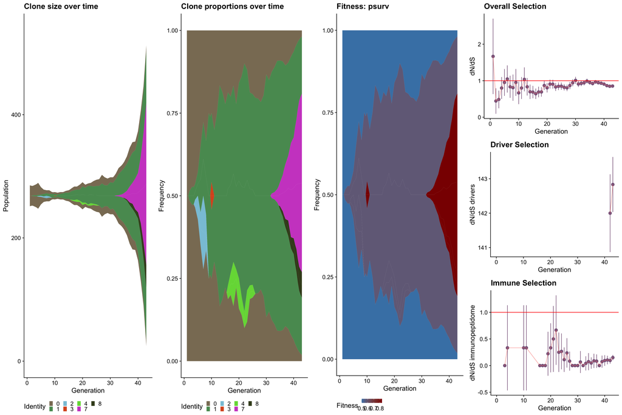

```r
p1
```

Another function to visualize dN/dS over time:

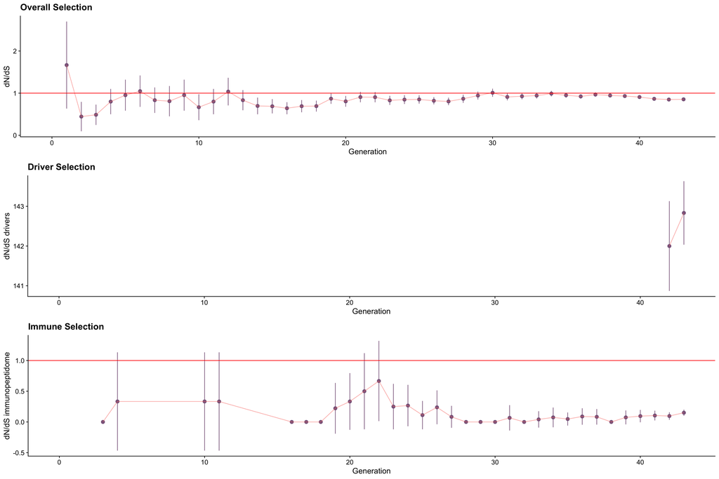

```r
#Visualize  dN/dS over time
dnds_plot(M)
```

We can aggregate the values corresponding to the major clones on the population and see how their dN/dS fluctuate over time

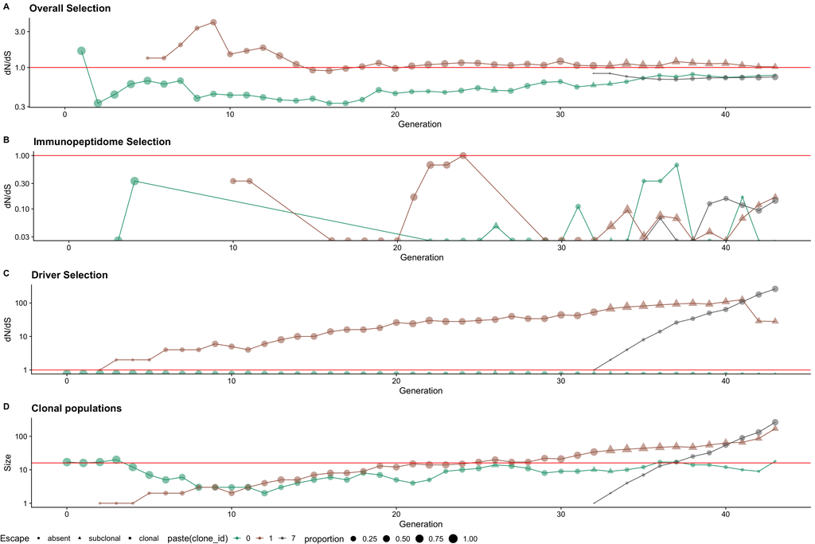

```r
#Visualize dN/dS over time using major clones
plot_clone_dnds(M)
```

## Running multiple simulations

```r
TASKS=10

PARAMS_RUN1 = lapply(1:TASKS,function(w) list(params))

RUNS = run(
  FUN = simulator,
  PARAMS = PARAMS_RUN1,
  silent = FALSE,
  parallel = TRUE,
  packages = c("ggpubr","tidyverse","ggmuller","crayon","pio")
)
```

Here, each of the single simulations can be plotted as shown before, but now we are more interested on the global behavior of multiple simulations over time. So we can use the following functions to summarise data over time.

```r
stats_dnds(RUNS)
```

```
#> # A tibble: 316 x 27
#>      t_0 median_dnds median_dndsi median_dndsd    dnds dnds_lci dnds_hci  dnds_i
#>    <dbl>       <dbl>        <dbl>        <dbl>   <dbl>    <dbl>    <dbl>   <dbl>
#>  1     0       1                1            1 NaN     NaN        NaN    NaN
#>  2     1      NA               NA           NA   0.667   0.0133     1.32 Inf
#>  3     2      NA               NA           NA   2.33    1.27       3.39 NaN
#>  4     3      NA               NA           NA Inf     NaN        Inf    Inf
#>  5     4     Inf               NA           NA   3.67    2.58       4.75 Inf
#>  6     5       0.667           NA           NA   1       0.307      1.69 Inf
#>  7     6       0.667           NA           NA   1       0.307      1.69 Inf
#>  8     7       1               NA           NA   1.5     0.776      2.22 Inf
#>  9     8       0.75            NA           NA   0.667   0.133      1.20   0
#> 10     9       0.833           NA           NA   0.867   0.437      1.30   0.333
#>    dnds_ilci dnds_ihci dnds_d dnds_dlci dnds_dhci count expon sum_na sum_ns
#>        <dbl>     <dbl>  <dbl>     <dbl>     <dbl> <int> <dbl>  <dbl>  <dbl>
```

[output cut: 23 more lines]

```r
evodevo(RUNS,4,500)
```

```
#> # A tibble: 10 x 6
#>    simulation_number  time event      fin_dnds fin_dndsd fin_dndsi
#>                <int> <dbl> <chr>         <dbl>     <dbl>     <dbl>
#>  1                 1    15 Extinction    2.08        0      0
#>  2                 2    34 Extinction    1.06        0      1.33
#>  3                 3    34 Expansion     1.97       20.9    0.138
#>  4                 4    38 Extinction    0.667       0      0
#>  5                 5    24 Expansion     0.699      54.8    0.0679
#>  6                 6    12 Extinction    0.167       0      0
#>  7                 7    37 Expansion     0.701      12.1    0.0444
#>  8                 8    36 Expansion     1.86       45.8    1.57
#>  9                 9    45 Expansion     0.579     192.     0.0440
#> 10                10    35 Expansion     0.778      33.8    0.348
```

The first function tell us the dN/dS with the confidence interval by taking all mutations present in alive cells at each time point

```r
all_genotypes<-lapply(RUNS,get_sequencing)
```

```
#> [1] "All cells dead at last time point"
#> [1] "All cells dead at last time point"
#> [1] "Cells are alive in last generation, compute dN/dS"
#> [1] "All cells dead at last time point"
#> [1] "Cells are alive in last generation, compute dN/dS"
#> [1] "All cells dead at last time point"
#> [1] "Cells are alive in last generation, compute dN/dS"
#> [1] "Cells are alive in last generation, compute dN/dS"
#> [1] "Cells are alive in last generation, compute dN/dS"
#> [1] "Cells are alive in last generation, compute dN/dS"
```

```r
calc_freq_dnds(RUNS,all_genotypes, freq = 0.05)
```

```
#> # A tibble: 6 x 14
#>   simulation   pop  time mut_na mut_ns mut_nad mut_nsd mut_nai mut_nsi mut_nae
#>        <int> <int> <dbl>  <int>  <int>   <int>   <int>   <int>   <int>   <int>
#> 1          3   518    34     35     10       2       0       0       2       0
#> 2          5   506    24     25     10       3       0       0       1       0
#> 3          7   698    37     23     10       3       1       0       1       0
#> 4          8   790    36     26      8       2       0       2       0       2
#> 5          9   622    45     30     20       3       0       0       2       0
#> 6         10   546    35     32     16       3       0       2       3       2
#>   dnds_global dnds_driver dnds_immune min_freq
#>         <dbl>       <dbl>       <dbl>    <dbl>
#> 1       1.17          Inf       0         0.05
#> 2       0.833         Inf       0         0.05
#> 3       0.767           1       0         0.05
#> 4       1.08          Inf     Inf         0.05
#> 5       0.5           Inf       0         0.05
#> 6       0.667         Inf       0.222     0.05
```

Here, you have a summary for each simulation, the number of the simulation, the last population size recorded, the time at which the last population size was recorded, the different nonsynonymous and synonymous mutations, the global, driver and immune dN/dS, and the cut-off frequency.